# DEV WTP betaseries: ISDN talk

Dani Cosme

2023-07-30

# prep

## load packages

```r
library(tidyverse)
library(lme4)
library(lmerTest)
library(knitr)
```

## define aesthetics

```r
algorithm = c("#006989", "#FEC601", "#F43C13", "#00A5CF", "#00A878")
food = c("#A4C960", "#2A5C8C")
liking = c("#FF0000", "#F2AD00")
bid = c("#00A08A", "#F2AD00", "#F98400", "#FF0000")
palette_condition = c("#685369", "#EEAC00", "#C1C3DE")
dc_bw = plot_aes = theme_minimal() +
  theme(legend.position = "top",
        legend.text = element_text(size = 12),
        text = element_text(size = 16, family = "Futura Medium"),
        panel.grid.major = element_blank(),
        panel.grid.minor = element_blank(),
        axis.text = element_text(color = "black"),
        axis.line = element_line(colour = "black"),
        axis.ticks.y = element_blank())
```

## define functions

```r
table_model = function(model_data) {
  model_data %>%
    broom.mixed::tidy(., conf.int = TRUE) %>%
    rename("SE" = std.error,
           "t" = statistic,
           "p" = p.value) %>%
    filter(effect == "fixed") %>%
    select(-group, -effect) %>%
    mutate_at(vars(-contains("term"), -contains("value")), round, 2) %>%
    mutate(term = gsub(":", " x ", term),
           term = gsub("dot_", "", term),
           term = gsub("liking_rating", "liking", term),
           term = gsub("wave1", "wave", term),
           term = gsub("healthunhealthy", "health (unhealthy)", term),
           term = gsub("conditionCognitive", "condition (cognitive)", term),
           term = gsub("conditionBehavioral", "condition (behavioral)", term),
           p = ifelse(p < .001, "< .001",
                      ifelse(p == 1, "1.000", gsub("0.(.*)", ".\\1", sprintf("%.3f", p)))),
           `b [95% CI]` = sprintf("%.2f [%0.2f, %.2f]", estimate, conf.low, conf.high)) %>%
    select(term, `b [95% CI]`, df, t, p) %>%
    kable()
}
```

## load and tidy task data

```r
task = read.csv("~/Documents/code/sanlab/DEV_scripts/fMRI/fx/multiconds/WTP/betaseries/events.csv", stringsAsFactors = FALSE) %>%
  mutate(bid = ifelse(bid == "NULL", NA, bid),
         bid = as.integer(bid),
         health = as.factor(health),
         liking = as.factor(liking)) %>%
  group_by(subjectID, wave, run) %>%
  mutate(trial = row_number()) %>%
  filter(wave %in% 1:2)
```

## check responses

Check if wrong buttons were used (i.e., not 5-8)

- DEV002 = wrong button box (i.e. 1-4) used
- DEV007 = wrong button box (i.e. 1-4) used
- DEV011 = code normally
- DEV017 = exclude; can’t tell if they’re missed responses or incorrect placement of fingers
- DEV019 = exclude; can’t tell if they’re missed responses or incorrect placement of fingers
- DEV032 = code normally
- DEV033 = incorrect placement of fingers; recode runs 1-3
- DEV054 = exclude; technical error?
- DEV061 = code normally

> NB! NEED TO GO THROUGH NEW PARTICPANTS/WAVES

```r
subs = task %>%
  mutate(bid = as.character(bid)) %>%
  group_by(subjectID, run, bid) %>%
  summarize(n = n()) %>%
  spread(bid, n) %>%
  mutate(messed = ifelse(!is.na(`2`), "yes", NA),
         messed = ifelse(is.na(`5`) & !is.na(`<NA>`), "yes", messed)) %>%
  filter(messed == "yes") %>%
  ungroup() %>%
  select(subjectID) %>%
  unique()

task %>%
  mutate(bid = as.character(bid)) %>%
  group_by(subjectID, run, bid) %>%
  summarize(n = n()) %>%
  spread(bid, n) %>%
  mutate(messed = ifelse(!is.na(`2`), "yes", NA),
         messed = ifelse(is.na(`5`) & !is.na(`<NA>`), "yes", messed)) %>%
  filter(subjectID %in% subs$subjectID)
```

| subjectID | run | 1 | 2 | 3 | 4 | 5 | 6 | 7 | 8 | <NA> | messed |
| --- | --- | --- | --- | --- | --- | --- | --- | --- | --- | --- | --- |
| DEV002 | run1 | 9 | 5 | 2 | NA | NA | NA | NA | NA | NA | yes |
| DEV002 | run2 | 6 | 8 | NA | 1 | NA | NA | NA | NA | 1 | yes |
| DEV002 | run3 | 4 | 7 | 5 | NA | NA | NA | NA | NA | NA | yes |
| DEV002 | run4 | 3 | 9 | 3 | 1 | NA | NA | NA | NA | NA | yes |
| DEV007 | run1 | NA | 9 | 6 | NA | NA | NA | NA | NA | 1 | yes |
| DEV007 | run2 | 1 | 5 | 6 | 4 | NA | NA | NA | NA | NA | yes |
| DEV007 | run3 | 1 | 7 | 5 | 3 | NA | NA | NA | NA | NA | yes |
| DEV007 | run4 | NA | 3 | 9 | 3 | NA | NA | NA | NA | 1 | yes |
| DEV011 | run1 | NA | NA | NA | NA | NA | 7 | 15 | 7 | 3 | yes |
| DEV011 | run2 | NA | NA | NA | NA | 1 | 10 | 15 | 6 | NA | NA |

[output cut: 30 more lines]

## recode and exclude

Recoding  
* DEV033: recode runs1-3, but if liking rating < 3, leave as missing

> NB! NEED TO GO THROUGH NEW PARTICPANTS/WAVES

```r
data.ex = task %>%
  mutate(bid = ifelse(subjectID == "DEV033" & wave == 1 & !run == "run4", bid - 1, bid),
         bid = ifelse(subjectID == "DEV033" & wave == 1 & !run == "run4" & is.na(bid) & liking_rating > 2, 8, bid),
         bid = (bid - 5) / 2) %>%
  group_by(subjectID, wave) %>%
  arrange(subjectID, run) %>%
  mutate(trial = row_number())
```

## load mean intensity values

```r
file_dir = "~/Documents/code/sanlab/DEV_scripts/fMRI/betaseries/WTP/dotProducts_WTP_wave1/"
file_pattern = "DEV[0-9]{3}_meanIntensity.txt"
file_list = list.files(file_dir, pattern = file_pattern)

intensities = data.frame()

for (file in file_list) {
  temp = tryCatch(read.table(file.path(file_dir,file), fill = TRUE) %>%
                    rename("subjectID" = V1,
                           "meanIntensity" = V3) %>%
                    extract(V2, "beta", "beta_([0-9]{4}).nii") %>%
                    mutate(beta = as.integer(beta),
                           wave = 1), error = function(e) message(file))
  intensities = rbind(intensities, temp)
  rm(temp)
}

file_dir = "~/Documents/code/sanlab/DEV_scripts/fMRI/betaseries/WTP/dotProducts_WTP_wave2/"
file_list = list.files(file_dir, pattern = file_pattern)
for (file in file_list) {
  temp = tryCatch(read.table(file.path(file_dir,file), fill = TRUE) %>%
                    rename("subjectID" = V1,
                           "meanIntensity" = V3) %>%
                    extract(V2, "beta", "beta_([0-9]{4}).nii") %>%
                    mutate(beta = as.integer(beta),
                           wave = 2), error = function(e) message(file))
  intensities = rbind(intensities, temp)
  rm(temp)
}
```

## load dot products

```r
file_dir = "~/Documents/code/sanlab/DEV_scripts/fMRI/betaseries/WTP/dotProducts_WTP_wave1/"
file_pattern = "DEV[0-9]{3}_dotProducts.txt"
file_list = list.files(file_dir, pattern = file_pattern)

dots = data.frame()

for (file in file_list) {
  temp = tryCatch(read.table(file.path(file_dir,file), fill = TRUE) %>%
                    rename("subjectID" = V1,
                           "map" = V3,
                           "dotProduct" = V4) %>%
                    extract(V2, "beta", "beta_([0-9]{4}).nii") %>%
                    extract(map, "algorithm", "(.*)_.*.nii") %>%
                    mutate(beta = as.integer(beta),
                            wave = 1), error = function(e) message(file))
  dots = rbind(dots, temp)
  rm(temp)
}

file_dir = "~/Documents/code/sanlab/DEV_scripts/fMRI/betaseries/WTP/dotProducts_WTP_wave2/"
file_list = list.files(file_dir, pattern = file_pattern)

for (file in file_list) {
  temp = tryCatch(read.table(file.path(file_dir,file), fill = TRUE) %>%
                    rename("subjectID" = V1,
                           "map" = V3,
                           "dotProduct" = V4) %>%
                    extract(V2, "beta", "beta_([0-9]{4}).nii") %>%
                    extract(map, "algorithm", "(.*)_.*.nii") %>%
                    mutate(beta = as.integer(beta),
                            wave = 2), error = function(e) message(file))
  dots = rbind(dots, temp)
  rm(temp)
}
```

## join intensities and dots

- recode trials with extreme intensities as NA

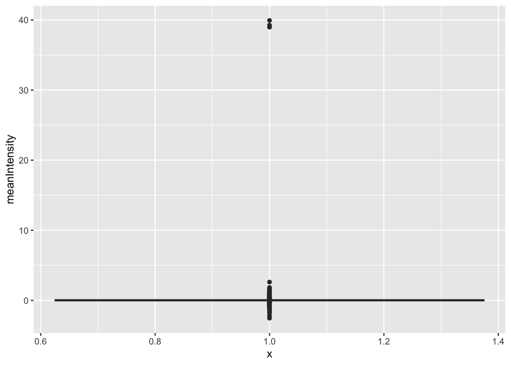

```r
dots.merged = dots %>%
  left_join(., intensities, by = c("subjectID", "wave", "beta")) %>%
  group_by(subjectID, wave, algorithm) %>%
  mutate(rownum = row_number())

# plot original
dots.merged %>%
  filter(algorithm == "craving_regulation") %>%
  ggplot(aes(1, meanIntensity)) +
    geom_boxplot()
```

```r
# assess extreme values and exclude when calculating SDs
dots.merged %>%
  filter(algorithm == "craving_regulation") %>%
  arrange(meanIntensity)
```

| subjectID | beta | algorithm | dotProduct | wave | meanIntensity | rownum |
| --- | --- | --- | --- | --- | --- | --- |
| DEV037 | 66 | craving_regulation | -27.16070000 | 1 | -2.5418100 | 51 |
| DEV047 | 27 | craving_regulation | -28.51030000 | 2 | -2.2040800 | 22 |
| DEV099 | 53 | craving_regulation | -25.67660000 | 2 | -1.7875500 | 43 |
| DEV047 | 28 | craving_regulation | -12.81760000 | 2 | -1.6409900 | 23 |
| DEV149 | 64 | craving_regulation | -14.81340000 | 2 | -1.5241100 | 49 |
| DEV028 | 2 | craving_regulation | -44.50280000 | 1 | -1.3053100 | 2 |
| DEV099 | 16 | craving_regulation | 22.55570000 | 2 | -1.2372900 | 16 |
| DEV099 | 24 | craving_regulation | -23.13690000 | 2 | -1.1699600 | 19 |
| DEV089 | 67 | craving_regulation | -48.47920000 | 1 | -1.1033600 | 52 |
| DEV099 | 25 | craving_regulation | -2.80679000 | 2 | -1.0779900 | 20 |

[output cut: 9990 more lines]

```r
dots.merged %>%
  filter(algorithm == "craving_regulation") %>%
  arrange(-meanIntensity)
```

| subjectID | beta | algorithm | dotProduct | wave | meanIntensity | rownum |
| --- | --- | --- | --- | --- | --- | --- |
| DEV082 | 64 | craving_regulation | 10.381300000 | 1 | 39.9291000 | 49 |
| DEV082 | 65 | craving_regulation | 30.421300000 | 1 | 39.2513000 | 50 |
| DEV082 | 66 | craving_regulation | -9.856990000 | 1 | 38.9626000 | 51 |
| DEV067 | 9 | craving_regulation | 34.814700000 | 2 | 2.6110200 | 9 |
| DEV267 | 76 | craving_regulation | 70.864200000 | 2 | 1.8353600 | 61 |
| DEV069 | 37 | craving_regulation | -46.210000000 | 1 | 1.7812900 | 32 |
| DEV099 | 8 | craving_regulation | -27.633100000 | 2 | 1.6793200 | 8 |
| DEV048 | 49 | craving_regulation | -4.675600000 | 1 | 1.5310600 | 39 |
| DEV067 | 7 | craving_regulation | -1.284290000 | 2 | 1.4945100 | 7 |
| DEV048 | 56 | craving_regulation | -15.843100000 | 1 | 1.4268200 | 46 |

[output cut: 9990 more lines]

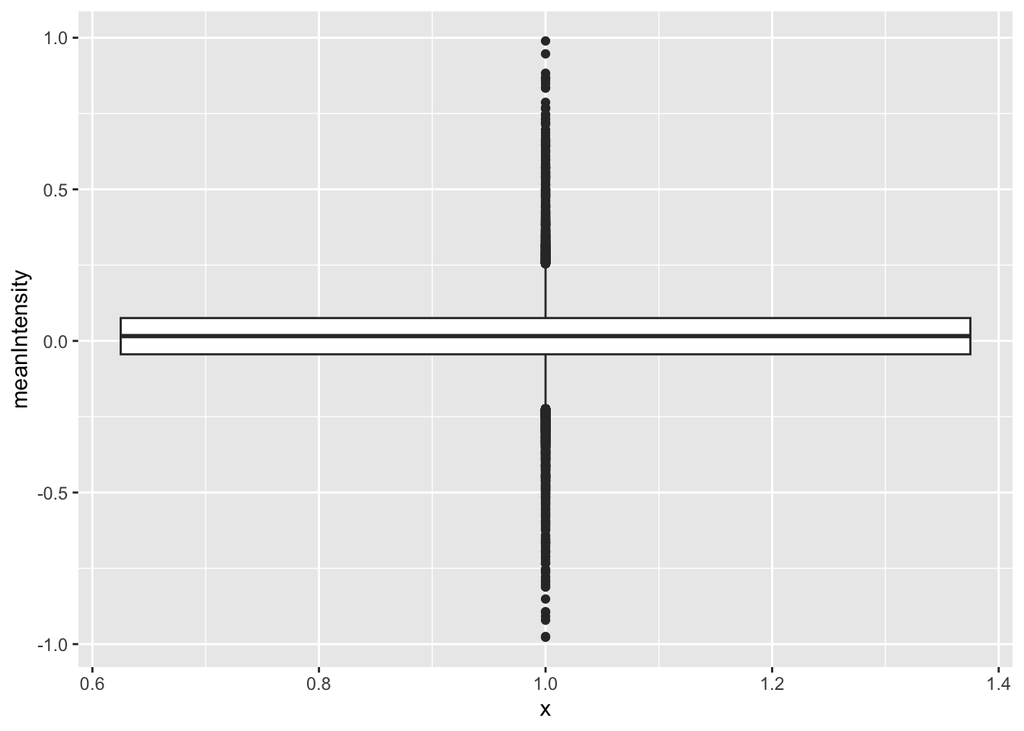

```r
# recode outliers as NA
dots.merged = dots.merged %>%
  ungroup() %>%
  mutate(meanIntensity = ifelse(meanIntensity > 1 | meanIntensity < -1, NA, meanIntensity),
         median = median(meanIntensity, na.rm = TRUE),
         sd3 = 3*sd(meanIntensity, na.rm = TRUE),
         outlier = ifelse(meanIntensity > median + sd3 | meanIntensity < median - sd3, "yes", "no"),
         dotProduct = ifelse(outlier == "yes", NA, dotProduct))

# plot after
dots.merged %>%
  filter(algorithm == "craving_regulation") %>%
  ggplot(aes(1, meanIntensity)) +
  geom_boxplot()
```

## exclude outliers and standardize

- standardize within algorithm and contrast

```r
dots.ex = dots.merged %>%
  group_by(algorithm, wave, subjectID) %>%
  mutate(trial = row_number())
```

## merge data

Exclusions

- Didn’t scan: DEV002, DEV007
- MRI motion and data quality exclusions: DEV001, DEV020, DEV032, DEV047, DEV063, DEV067, DEV078
- Button box exclusions: DEV017, DEV019, DEV054
- Run exclusions: DEV028 (run1), DEV048 (run3), DEV064 (run1), DEV069 (run1)

> NB! NEED TO GO THROUGH NEW PARTICPANTS/WAVES

```r
conditions = read.csv("~/Desktop/dev_conditions.csv")

data_all = left_join(dots.ex, data.ex, by = c("subjectID", "wave", "trial")) %>%
  filter(!subjectID %in% c("DEV002", "DEV007", "DEV001", "DEV020", "DEV032", "DEV047", "DEV063", "DEV067", "DEV078", "DEV017", "DEV019", "DEV054")) %>%
  filter(!(subjectID == "DEV028" & run == "run1" & wave == 1) & !(subjectID == "DEV048" & run == "run3" & wave == 1) &
         !(subjectID == "DEV064" & run == "run1" & wave == 1) & !(subjectID == "DEV069" & run == "run1" & wave == 1)) %>%
  ungroup() %>%
  ungroup() %>%
  mutate(algorithm = gsub("_signature", "", algorithm),
         wave = as.character(wave),
         liking = ifelse(liking_rating > 2, "liked",
                  ifelse(liking_rating < 3, "disliked", NA))) %>%
  filter(!is.na(health)) %>%
  left_join(., conditions) %>%
  filter(condition %in% c("Cognitive", "Control")) %>%
  mutate(condition = recode(condition, "Cognitive" = "Reappraisal"),
         wave = as.numeric(recode(wave, "1" = "0", "2" = "1")))

data = data_all %>%
  filter(liking == "liked") %>%
  filter(algorithm == "nsc_koban") %>%
  filter(health == "healthy")
```

# descriptives

## number of participants

```r
data %>%
  select(subjectID, wave) %>%
  unique() %>%
  group_by(wave) %>%
  summarize(n = n())
```

| wave | n |
| --- | --- |
| 0 | 174 |
| 1 | 151 |

## bids

### across waves

```r
data %>%
  group_by(health) %>%
  summarize(n = n(),
            mean = round(mean(bid, na.rm = TRUE), 2),
            sd = round(sd(bid, na.rm = TRUE), 2),
            min = min(bid, na.rm = TRUE),
            max = max(bid, na.rm = TRUE)) %>%
  kable(format = "pandoc")
```

| health | n | mean | sd | min | max |
| --- | --- | --- | --- | --- | --- |
| healthy | 5398 | 1.04 | 0.42 | 0 | 1.5 |

### by wave

```r
data %>%
  group_by(wave, health) %>%
  summarize(n = n(),
            mean = round(mean(bid, na.rm = TRUE), 2),
            sd = round(sd(bid, na.rm = TRUE), 2),
            min = min(bid, na.rm = TRUE),
            max = max(bid, na.rm = TRUE)) %>%
  kable(format = "pandoc")
```

| wave | health | n | mean | sd | min | max |
| --- | --- | --- | --- | --- | --- | --- |
| 0 | healthy | 2866 | 1.03 | 0.42 | 0 | 1.5 |
| 1 | healthy | 2532 | 1.06 | 0.42 | 0 | 1.5 |

## session 0 liking ratings

```r
data_all %>%
  group_by(health) %>%
  summarize(n = n(),
            mean = round(mean(liking_rating, na.rm = TRUE), 2),
            sd = round(sd(liking_rating, na.rm = TRUE), 2),
            min = min(liking_rating, na.rm = TRUE),
            max = max(liking_rating, na.rm = TRUE)) %>%
  kable(format = "pandoc")
```

| health | n | mean | sd | min | max |
| --- | --- | --- | --- | --- | --- |
| healthy | 31089 | 2.58 | 1.19 | 0 | 4 |
| unhealthy | 31098 | 2.24 | 1.24 | 0 | 4 |

# MLM

Disaggregate within and between person relationships

- `dot_between` = grand mean centered person average signature expression
- `dot_within` = person-centered signature expression

```r
between = data %>%
  group_by(condition, wave, subjectID, algorithm) %>%
  summarize(dot_between = mean(dotProduct, na.rm = TRUE),
            variability = var(dotProduct, na.rm = TRUE)) %>%
  ungroup() %>%
  mutate(dot_between = scale(dot_between, center = TRUE, scale = TRUE),
         var_between = scale(variability, center = TRUE, scale = TRUE))

data_diss = data %>%
  group_by(wave, subjectID, algorithm) %>%
  mutate(dot_within = scale(dotProduct, center = TRUE, scale = TRUE)) %>%
  left_join(., between) %>%
  select(condition, subjectID, wave, trial, bid, algorithm, dotProduct, dot_within, dot_between, var_between)
```

# no brain

## bid ~ wave x condition

### tidytable

```r
mod_bid = lmer(bid ~ wave * condition + (1 + wave | subjectID),
                  data = data_diss,
                  control = lmerControl(optimizer = "bobyqa"))
table_model(mod_bid)
```

| term | b [95% CI] | df | t | p |
| --- | --- | --- | --- | --- |
| (Intercept) | 1.00 [0.96, 1.05] | 169.55 | 45.33 | < .001 |
| wave | 0.02 [-0.03, 0.06] | 139.79 | 0.71 | .480 |
| conditionReappraisal | 0.02 [-0.04, 0.08] | 167.60 | 0.67 | .500 |
| wave x conditionReappraisal | 0.03 [-0.04, 0.09] | 137.70 | 0.84 | .400 |

### plot

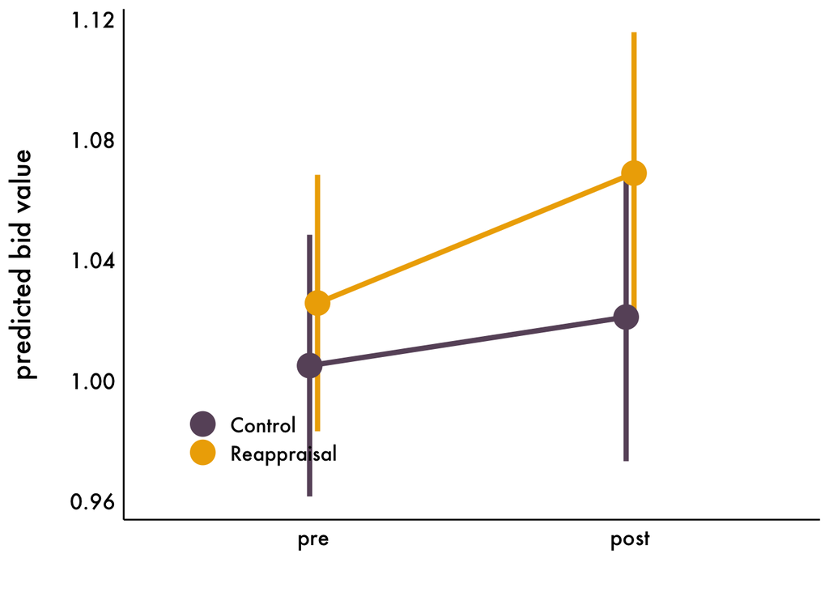

```r
ggeffects::ggpredict(mod_bid, terms = c("wave", "condition")) %>%
  data.frame() %>%
  mutate(x = recode(x, "0" = "pre", "1" = "post"),
         x = factor(x, levels = c("pre", "post"))) %>%
  ggplot(aes(x, predicted, color = group, fill = group)) +
  geom_pointrange(aes(ymin = conf.low, ymax = conf.high), size = 1.5, linewidth = 1.5, position = position_dodge(.05)) +
  geom_line(aes(group = group), size = 1.5, position = position_dodge(.05)) +
  scale_color_manual(name = "", values = palette_condition) +
  scale_fill_manual(name = "", values = palette_condition) +
  labs(x = "", y = "predicted bid value\n") +
  #scale_y_continuous(limits = c(0.65, 1.1)) +
  dc_bw +
  theme(legend.position = c(.2, .2))
```

### model summary

```r
summary(mod_bid)
```

```
## Linear mixed model fit by REML. t-tests use Satterthwaite's method [
## lmerModLmerTest]
## Formula: bid ~ wave * condition + (1 + wave | subjectID)
##    Data: data_diss
## Control: lmerControl(optimizer = "bobyqa")
##
## REML criterion at convergence: 5118.1
##
## Scaled residuals:
##     Min      1Q  Median      3Q     Max
## -3.2566 -0.5764  0.0632  0.8151  2.2160
##
## Random effects:
##  Groups    Name        Variance Std.Dev. Corr
##  subjectID (Intercept) 0.03141  0.1772
##            wave        0.01894  0.1376   -0.30
##  Residual              0.14762  0.3842
## Number of obs: 5055, groups:  subjectID, 176
##
## Fixed effects:
##                            Estimate Std. Error        df t value
## (Intercept)                 1.00483    0.02217 169.55376  45.331
## wave                        0.01613    0.02285 139.79241   0.706
## conditionReappraisal        0.02077    0.03104 167.59921   0.669
## wave:conditionReappraisal   0.02701    0.03200 137.70007   0.844
##                                      Pr(>|t|)
## (Intercept)               <0.0000000000000002 ***
## wave                                    0.481
## conditionReappraisal                    0.504
## wave:conditionReappraisal               0.400
## ---
## Signif. codes:  0 '***' 0.001 '**' 0.01 '*' 0.05 '.' 0.1 ' ' 1
##
## Correlation of Fixed Effects:
##             (Intr) wave   cndtnR
## wave        -0.412
## cndtnRpprsl -0.714  0.294
## wv:cndtnRpp  0.294 -0.714 -0.414
```

# craving regulation

## brain ~ condition x wave

### tidytable

```r
mod_dot = lmer(dotProduct ~ wave * condition + (1 + wave | subjectID),
                  data = data_diss,
                  control = lmerControl(optimizer = "bobyqa"))
table_model(mod_dot)
```

| term | b [95% CI] | df | t | p |
| --- | --- | --- | --- | --- |
| (Intercept) | 2.39 [1.73, 3.05] | 164.26 | 7.14 | < .001 |
| wave | 0.16 [-0.55, 0.88] | 143.24 | 0.46 | .650 |
| conditionReappraisal | 0.18 [-0.75, 1.11] | 163.49 | 0.39 | .700 |
| wave x conditionReappraisal | 0.15 [-0.85, 1.15] | 141.75 | 0.29 | .770 |

### plot

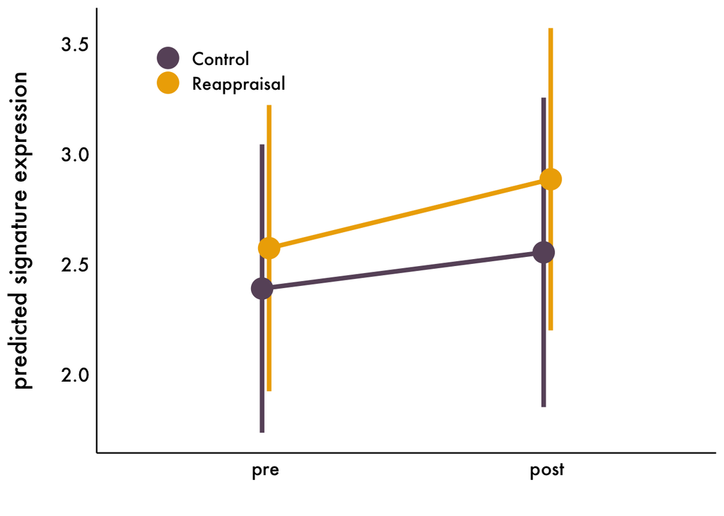

```r
ggeffects::ggpredict(mod_dot, terms = c("wave", "condition")) %>%
  data.frame() %>%
  mutate(x = recode(x, "0" = "pre", "1" = "post"),
         x = factor(x, levels = c("pre", "post"))) %>%
  ggplot(aes(x, predicted, color = group, fill = group)) +
  geom_pointrange(aes(ymin = conf.low, ymax = conf.high), size = 1.5, linewidth = 1.5, position = position_dodge(.05)) +
  geom_line(aes(group = group), size = 1.5, position = position_dodge(.05)) +
  scale_color_manual(name = "", values = palette_condition) +
  scale_fill_manual(name = "", values = palette_condition) +
  #scale_y_continuous(limits = c(-6, -1.5)) +
  labs(x = "", y = "predicted signature expression\n") +
  dc_bw +
  theme(legend.position = c(.2, .9))
```

### model summary

```r
summary(mod_dot)
```

```
## Linear mixed model fit by REML. t-tests use Satterthwaite's method [
## lmerModLmerTest]
## Formula: dotProduct ~ wave * condition + (1 + wave | subjectID)
##    Data: data_diss
## Control: lmerControl(optimizer = "bobyqa")
##
## REML criterion at convergence: 35259.8
##
## Scaled residuals:
##     Min      1Q  Median      3Q     Max
## -5.5809 -0.6031  0.0033  0.6127  5.0924
##
## Random effects:
##  Groups    Name        Variance Std.Dev. Corr
##  subjectID (Intercept)  6.971   2.640
##            wave         4.688   2.165    -0.39
##  Residual              41.275   6.425
## Number of obs: 5318, groups:  subjectID, 177
##
## Fixed effects:
##                           Estimate Std. Error       df t value        Pr(>|t|)
## (Intercept)                 2.3865     0.3340 164.2560   7.145 0.0000000000279
## wave                        0.1643     0.3607 143.2409   0.456           0.649
## conditionReappraisal        0.1835     0.4706 163.4905   0.390           0.697
## wave:conditionReappraisal   0.1486     0.5065 141.7493   0.293           0.770
##
## (Intercept)               ***
## wave
## conditionReappraisal
## wave:conditionReappraisal
## ---
## Signif. codes:  0 '***' 0.001 '**' 0.01 '*' 0.05 '.' 0.1 ' ' 1
##
## Correlation of Fixed Effects:
##             (Intr) wave   cndtnR
## wave        -0.470
## cndtnRpprsl -0.710  0.333
## wv:cndtnRpp  0.335 -0.712 -0.476
```

## brain variability ~ condition x wave

### tidytable

```r
mod_var = lmer(var_between ~ wave * condition + (1 | subjectID),
                  data = between,
                  control = lmerControl(optimizer = "bobyqa"))
table_model(mod_var)
```

| term | b [95% CI] | df | t | p |
| --- | --- | --- | --- | --- |
| (Intercept) | -0.24 [-0.44, -0.03] | 308.29 | -2.22 | .030 |
| wave | 0.50 [0.23, 0.78] | 164.40 | 3.59 | < .001 |
| conditionReappraisal | 0.26 [-0.03, 0.55] | 309.13 | 1.74 | .080 |
| wave x conditionReappraisal | -0.54 [-0.93, -0.15] | 165.91 | -2.76 | .010 |

### plot

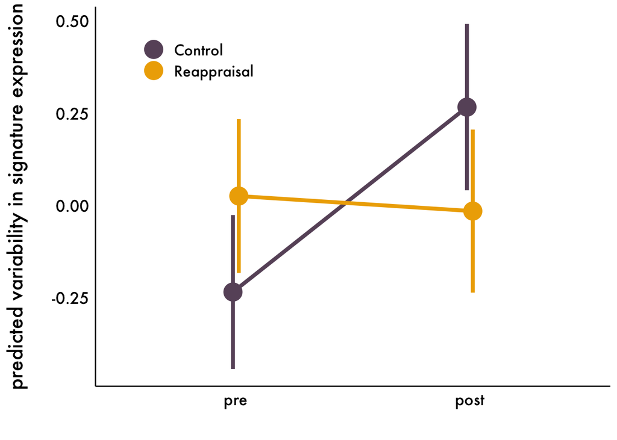

```r
ggeffects::ggpredict(mod_var, terms = c("wave", "condition")) %>%
  data.frame() %>%
  mutate(x = recode(x, "0" = "pre", "1" = "post"),
         x = factor(x, levels = c("pre", "post"))) %>%
  ggplot(aes(x, predicted, color = group, fill = group)) +
  geom_pointrange(aes(ymin = conf.low, ymax = conf.high), size = 1.5, linewidth = 1.5, position = position_dodge(.05)) +
  geom_line(aes(group = group), size = 1.5, position = position_dodge(.05)) +
  scale_color_manual(name = "", values = palette_condition) +
  scale_fill_manual(name = "", values = palette_condition) +
  labs(x = "", y = "predicted variability in signature expression\n") +
  dc_bw +
  theme(legend.position = c(.2, .9))
```

### model summary

```r
summary(mod_dot)
```

```
## Linear mixed model fit by REML. t-tests use Satterthwaite's method [
## lmerModLmerTest]
## Formula: dotProduct ~ wave * condition + (1 + wave | subjectID)
##    Data: data_diss
## Control: lmerControl(optimizer = "bobyqa")
##
## REML criterion at convergence: 35259.8
##
## Scaled residuals:
##     Min      1Q  Median      3Q     Max
## -5.5809 -0.6031  0.0033  0.6127  5.0924
##
## Random effects:
##  Groups    Name        Variance Std.Dev. Corr
##  subjectID (Intercept)  6.971   2.640
##            wave         4.688   2.165    -0.39
##  Residual              41.275   6.425
## Number of obs: 5318, groups:  subjectID, 177
##
## Fixed effects:
##                           Estimate Std. Error       df t value        Pr(>|t|)
## (Intercept)                 2.3865     0.3340 164.2560   7.145 0.0000000000279
## wave                        0.1643     0.3607 143.2409   0.456           0.649
## conditionReappraisal        0.1835     0.4706 163.4905   0.390           0.697
## wave:conditionReappraisal   0.1486     0.5065 141.7493   0.293           0.770
##
## (Intercept)               ***
## wave
## conditionReappraisal
## wave:conditionReappraisal
## ---
## Signif. codes:  0 '***' 0.001 '**' 0.01 '*' 0.05 '.' 0.1 ' ' 1
##
## Correlation of Fixed Effects:
##             (Intr) wave   cndtnR
## wave        -0.470
## cndtnRpprsl -0.710  0.333
## wv:cndtnRpp  0.335 -0.712 -0.476
```

## bid ~ brain x wave x condition

### tidy table

```r
mod_bid_diss = lmer(bid ~ dot_between * wave * condition + dot_within * wave * condition + (1 + dot_within + wave | subjectID),
               data = data_diss,
               control = lmerControl(optimizer = "bobyqa"))
table_model(mod_bid_diss)
```

| term | b [95% CI] | df | t | p |
| --- | --- | --- | --- | --- |
| (Intercept) | 1.01 [0.96, 1.05] | 167.43 | 45.71 | < .001 |
| between | 0.05 [0.01, 0.09] | 181.63 | 2.20 | .030 |
| wave | 0.02 [-0.03, 0.06] | 137.44 | 0.73 | .470 |
| conditionReappraisal | 0.02 [-0.04, 0.08] | 165.73 | 0.73 | .470 |
| within | 0.08 [0.05, 0.10] | 510.88 | 6.68 | < .001 |
| between x wave | 0.00 [-0.05, 0.06] | 199.33 | 0.17 | .860 |
| between x conditionReappraisal | -0.03 [-0.09, 0.03] | 180.41 | -1.09 | .280 |
| wave x conditionReappraisal | 0.02 [-0.04, 0.08] | 137.07 | 0.62 | .540 |
| wave x within | -0.03 [-0.06, 0.00] | 4640.84 | -1.83 | .070 |
| conditionReappraisal x within | -0.02 [-0.05, 0.01] | 471.48 | -1.05 | .300 |
| between x wave x conditionReappraisal | 0.02 [-0.05, 0.10] | 199.58 | 0.56 | .580 |
| wave x conditionReappraisal x within | 0.01 [-0.03, 0.05] | 4588.59 | 0.40 | .690 |

### plot

#### by wave

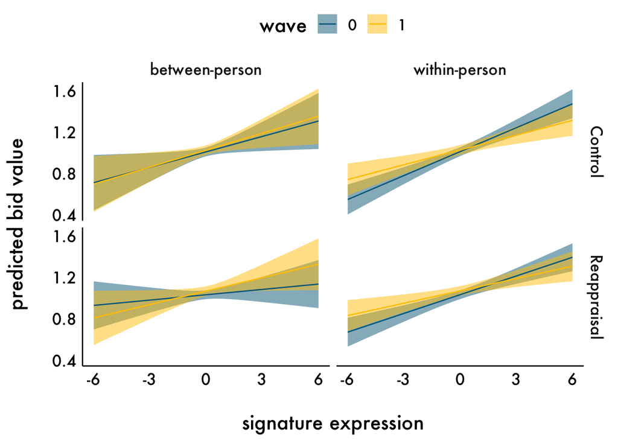

```r
vals = seq(-6, 6, .2)
ggeffects::ggpredict(mod_bid_diss, terms = c("dot_between[vals]", "wave", "condition")) %>%
  data.frame() %>%
  mutate(type = "between-person") %>%
  bind_rows(ggeffects::ggpredict(mod_bid_diss, terms = c("dot_within[vals]", "wave", "condition")) %>%
              data.frame() %>%
              mutate(type = "within-person")) %>%
  ggplot(aes(x, predicted, color = group, fill = group)) +
  geom_ribbon(aes(ymin = conf.low, ymax = conf.high), alpha = .5, color = NA) +
  geom_line(aes(group = group)) +
  facet_grid(facet~type) +
  scale_color_manual(name = "wave", values = algorithm) +
  scale_fill_manual(name = "wave", values = algorithm) +
  labs(x = "\nsignature expression", y = "predicted bid value\n") +
  dc_bw
```

#### by expression

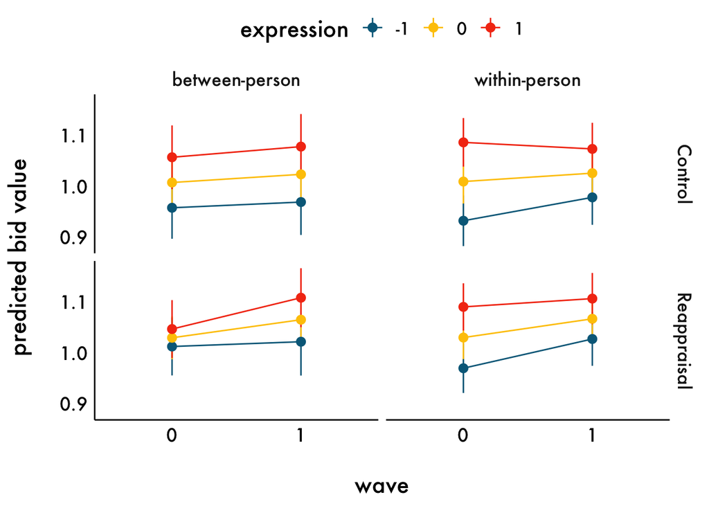

```r
ggeffects::ggpredict(mod_bid_diss, terms = c("wave", "dot_between [-1, 0, 1]", "condition")) %>%
  data.frame() %>%
  mutate(type = "between-person") %>%
  bind_rows(ggeffects::ggpredict(mod_bid_diss, terms = c("wave", "dot_within [-1, 0, 1]", "condition")) %>%
              data.frame() %>%
              mutate(type = "within-person")) %>%
  mutate(x = as.factor(x)) %>%
  ggplot(aes(x, predicted, color = group, fill = group)) +
  geom_pointrange(aes(ymin = conf.low, ymax = conf.high)) +
  geom_line(aes(group = group)) +
  facet_grid(facet~type) +
  scale_color_manual(name = "expression", values = algorithm) +
  scale_fill_manual(name = "expression", values = algorithm) +
  labs(x = "\nwave", y = "predicted bid value\n") +
  dc_bw
```

#### pre-post change

##### between-person

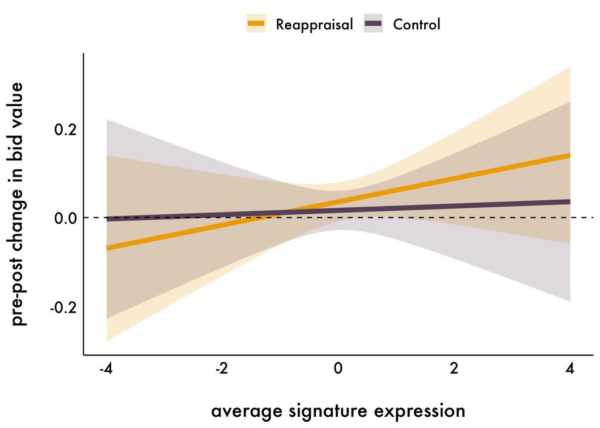

```r
palette_condition = c("#EEAC00", "#685369", "#C1C3DE")
modelbased::estimate_contrasts(mod_bid_diss, "wave=c(1,0)", at = c("condition", "dot_between=seq(-4,4,.2)")) %>%
  data.frame() %>%
  ggplot(aes(x = dot_between, y = Difference)) +
  geom_ribbon(aes(fill = condition, ymin = CI_low, ymax = CI_high), alpha = 0.2) +
  geom_line(aes(colour = condition), size = 2) +
  geom_hline(yintercept = 0, linetype = "dashed") +
  scale_color_manual(name = "", values = palette_condition) +
  scale_fill_manual(name = "", values = palette_condition) +
  labs(x = "\naverage signature expression", y = "pre-post change in bid value\n") +
  dc_bw
```

##### within-person

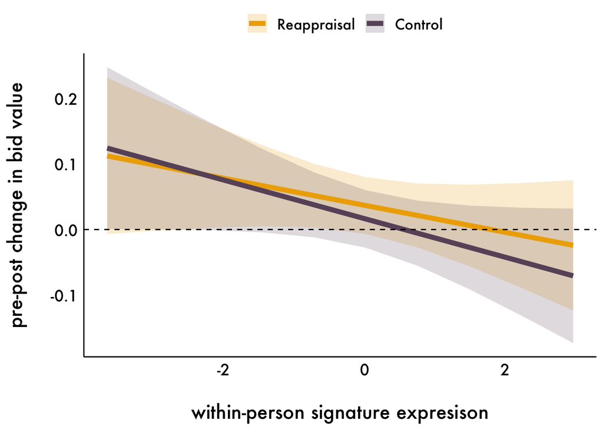

```r
modelbased::estimate_contrasts(mod_bid_diss, "wave=c(1,0)", at = c("condition", "dot_within")) %>%
  data.frame() %>%
  ggplot(aes(x = dot_within, y = Difference)) +
  geom_ribbon(aes(fill = condition, ymin = CI_low, ymax = CI_high), alpha = 0.2) +
  geom_line(aes(colour = condition), size = 2) +
  geom_hline(yintercept = 0, linetype = "dashed") +
  scale_color_manual(name = "", values = palette_condition) +
  scale_fill_manual(name = "", values = palette_condition) +
  labs(x = "\nwithin-person signature expresison", y = "pre-post change in bid value\n") +
  dc_bw
```

### model summary

```r
summary(mod_bid_diss)
```

```
## Linear mixed model fit by REML. t-tests use Satterthwaite's method [
## lmerModLmerTest]
## Formula:
## bid ~ dot_between * wave * condition + dot_within * wave * condition +
##     (1 + dot_within + wave | subjectID)
##    Data: data_diss
## Control: lmerControl(optimizer = "bobyqa")
##
## REML criterion at convergence: 4958
##
## Scaled residuals:
##     Min      1Q  Median      3Q     Max
## -3.3933 -0.5805  0.0534  0.7988  2.3894
##
## Random effects:
##  Groups    Name        Variance Std.Dev. Corr
##  subjectID (Intercept) 0.03098  0.17600
##            dot_within  0.00108  0.03287  -0.19
##            wave        0.01757  0.13257  -0.31 -0.03
##  Residual              0.14304  0.37821
## Number of obs: 4977, groups:  subjectID, 176
##
## Fixed effects:
##                                          Estimate  Std. Error          df
## (Intercept)                              1.005853    0.022005  167.432096
## dot_between                              0.049678    0.022595  181.634593
## wave                                     0.016305    0.022333  137.435236
## conditionReappraisal                     0.022436    0.030815  165.729095
## dot_within                               0.077100    0.011537  510.884842
## dot_between:wave                         0.004860    0.028075  199.326542
## dot_between:conditionReappraisal        -0.032509    0.029800  180.411004
## wave:conditionReappraisal                0.019364    0.031486  137.071023
## wave:dot_within                         -0.029433    0.016040 4640.838538
## conditionReappraisal:dot_within         -0.016776    0.016012  471.475373
## dot_between:wave:conditionReappraisal    0.021244    0.037889  199.575269
## wave:conditionReappraisal:dot_within     0.008837    0.022274 4588.593289
##                                       t value             Pr(>|t|)
## (Intercept)                            45.710 < 0.0000000000000002 ***
## dot_between                             2.199               0.0292 *
## wave                                    0.730               0.4666
```

[output cut: 22 more lines]

```
## cndtnRppr:_  0.037  0.002  0.004 -0.054 -0.721  0.000 -0.001 -0.004  0.466
## dt_btwn:w:R  0.016  0.462 -0.001 -0.009  0.000 -0.741 -0.602 -0.059  0.003
## wv:cndtnR:_  0.000 -0.002  0.007  0.002  0.466  0.003  0.000 -0.009 -0.720
##             cndR:_ dt_::R
## dot_between
## wave
## cndtnRpprsl
## dot_within
## dot_btwn:wv
## dt_btwn:cnR
## wv:cndtnRpp
## wav:dt_wthn
## cndtnRppr:_
## dt_btwn:w:R  0.000
## wv:cndtnR:_ -0.645 -0.002
```